# Introdução à Inferência Estatística

2024

# 1. Elementos Básicos

## 1.1 Estimadores

**Definição 1.1.**

*Qualquer função da amostra que não depende de parâmetros desconhecidos é denominada uma estatística.*

**Definição 1.2.**

*Qualquer estatística que assuma valores dentro do espaço paramétrico é um estimador para o parâmetro*

Comumente vemos o parâmetro representado por $\theta$ e o estimador desse mesmo parametro por um chapeu $\hat{\theta}$

#### 1.2 Exemplo

Dado o seguinte estimador da variancia

$$\hat{\sigma}^2 = \frac{1}{n} \sum_{i=1}^{n} (x_i - \bar{x})^2$$

Queremos verificar se ela tende ao verdadeiro valor da variancia populacional

$$\sigma^2 = \frac{1}{N} \sum_{i=1}^{N} (x_i - \bar{x})^2$$

Não é dificil provar que a esperança e variancia do estimador é:
$$E[\hat{\sigma}] = \frac{n-1}{n}\sigma^2 \\
V[\hat{\sigma}] = \frac{n-1}{n^2}2\sigma^4$$

Temos um estimador viesado, porem assintoticamente não-viesado. Visto que existem estimadores muito mais complexos que esse, as vezes pode ser dificil obter uma soluação analitica. Dado esse fato, sera usado a teoria para replicar situações probabilisticas afim de chegar nos resultados teoricos demonstrados

**Para as simulações será usado**

1. Uma população de uma distribuição normal com $\mu=12.5$ e $\sigma=7.5$
2. Amostra da distribuição de tamanho 100
3. Serão realizadas 10.000 simulações para gerar a distribuição do estimador que será usado para o calculo da esperança e variancia
4. O resultado teorico da média e variância será destacado em verde nos graficos

*Obs. Os resultados não se aplicam apenas para uma população com distribuição normal, mas para qualquer outra distribuição*

Caso não disponha do modelo probabilistico dos dados, mas apenas da amostra, uma solução simples é usar o Bootstrapping ou algo mais elaborado é ajustar os dados a um modelo existente.

```r
#variancia
variancia <- function(x) {
  erro.quadratico = (x - mean(x))^2

  return(mean(erro.quadratico))
}

#Estimador da variancia
estimador.var <- function(amostra) {
  erro.quadratico = (amostra - mean(amostra))^2

  return(mean(erro.quadratico))
}
```

Vamos gerar uma amostra da distribuição normal e calcular nosso estimador $\hat{\sigma}^2$ para essa amostra. Repetiremos esse passo 10.000 vezes

```r
#Simulando
tamanho_amostra = 100
media = 12.5
desv_padrao = 7.5
estimador = vector()

set.seed(1252752)
for (i in 1:10000) {
  amostra = rnorm(n = tamanho_amostra, mean = media, sd = desv_padrao)
  estimador[i] = estimador.var(amostra)
}
```

Para $E[\hat{\sigma}]$ vamos calcular a média das estimativas geradas em cada simulação. De forma semelhante será calculado a variancia para obter $Var[\hat{\sigma}]$. Assim temos:

```r
cat('\n Média do estimador:', mean(estimador), '\n',
    'Variância do estimador:', estimador.var(estimador), '\n')
```

```
##
##  Média do estimador: 55.67329
##  Variância do estimador: 61.97255
```

```r
restimador <- function(fun.estimador,
                       dist = rnorm,
                       parametros_dist = list(mean=12.5, sd=7.5),
                       tamanho_amostra = 100,
                       n_simulacoes = 10000
                       ) {

  for (i in 1:n_simulacoes) {
    #estou considerando que os geradores de distribuiçoes possuem a seguinte sequencia de parametros (n, demais parametros)
    amostra = dist(tamanho_amostra,
                   parametros_dist$mean, parametros_dist$sd)

    estimador[i] = fun.estimador(amostra)
  }

  return(estimador)
}
```

```r
#Distribuiçao da amostra para tamanho de amostras diferentes
DistEst_NAmostra <- function(fun.estimador,
                           dist = rnorm,
                           parametros_dist = list(mean=12.5, sd=7.5),
                           tamanho_amostra = seq(100, 1000, 100),
                           n_simulacoes = 10000
                           ) {

  m = length(tamanho_amostra)
  esperanca_n = variancia_n = vector()

  for (i in 1:m) {
    estimador = vector()

  #rodando a distribuiçao padrao > normal(12.5, 7.5^2) com 1000 simul
   estimador = restimador(fun.estimador   = fun.estimador,
                          dist            = dist,
                          parametros_dist = parametros_dist,
                          tamanho_amostra = tamanho_amostra[i],
                          n_simulacoes    = n_simulacoes)

    #média do estimador para o numero do tamanho_amostra[j]
    esperanca_n[i] = mean(estimador)
    variancia_n[i] = variancia(estimador)
  }


  return(data.frame(n=tamanho_amostra,
                    esperanca=esperanca_n,
                    variancia=variancia_n))
}
```

```r
#dados da simulação
n_amostra = seq(1, 100, 1)

set.seed(1252752)
simulacao = DistEst_NAmostra(fun.estimador   = estimador.var,
                             tamanho_amostra = n_amostra,
                             n_simulacoes    = 10000)

#Valor teorico (livro bolfarine)
esperanca.estimador_var = function(n, var) var*(n-1)/n
variancia.estimador_var = function(n, var) 2*var^2*(n-1)/n^2
```

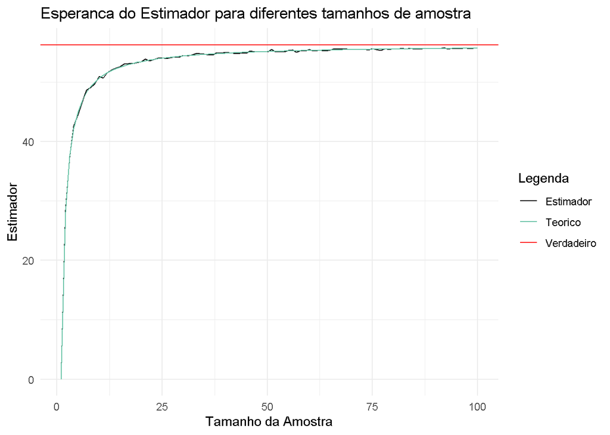

O estimador é assintoticamente não-viesado, pois tende ao verdadeiro valor a medida que aumentamos o tamanho da amostra. Analisaremos a variancia

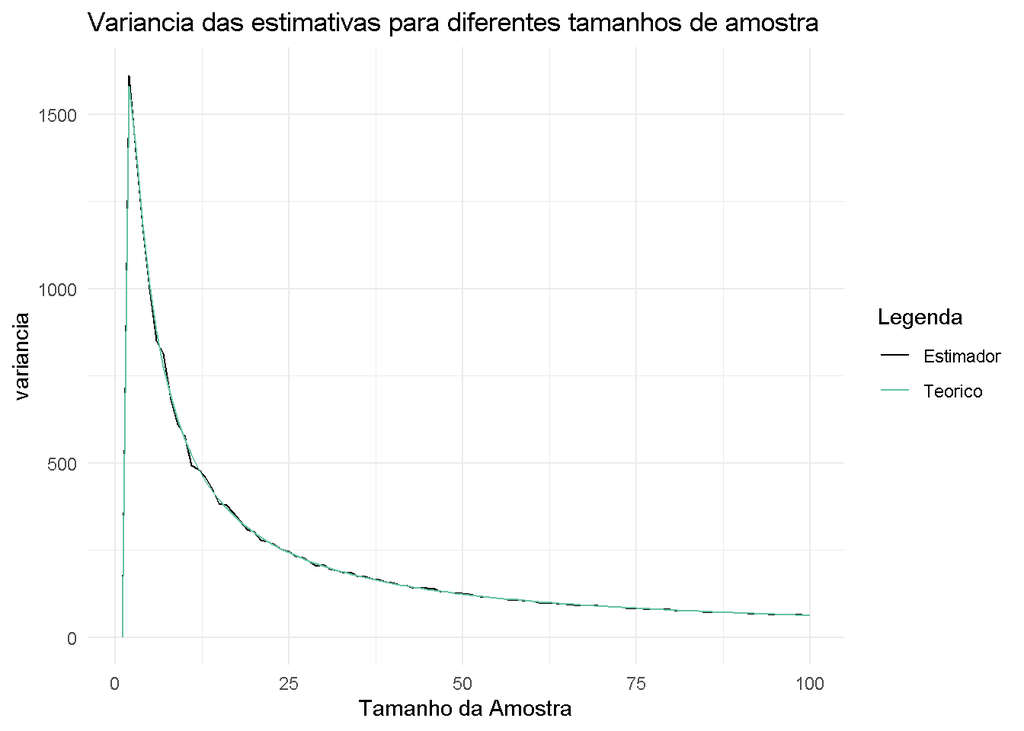

Observa-se que a variancia do estimador tende a zero quanto maior o tamanho da amostra

## 1.2 Erro Quadrático Médio (EQM)

Exitem muitas formas de escrever um estimador, por isso é importante identificar as propriedades desse parametro, como o erro que ele comete, isto é, o quanto ele se afasta do verdadeiro valor.

Uma forma simples de fazer isso é calculando o erro absoluto $EA_{\theta}(estimador) = |estimador - parâmetro|$, ele é fiel ao erro porem matematicamente é um pouco complicado e temos menos recursos matematicos/estatísticos para trabalhar com essa função, por outro lado o erro quadratico $EQ_{\theta}(estimador) = (estimador - parâmetro)^2$ tem uma basta gama de teoremas e é matematicamente mais simples de trabalhar. Uma propriedade importante dessa função é que ela penaliza muito os erros grotescos, aquele onde o valor estimado se afasta muito do real.

```r
#Gerando a distribuição do estimador da variancia

#por padrão a função usa os seguintes parametros
#média = 12.5
#var = 7.5^2
#tamanho da mostra = 100

#fixando semente
set.seed(1252752)
Dist_EstVar = restimador(fun.estimador = estimador.var,
                         n_simulacoes = 1000)
```

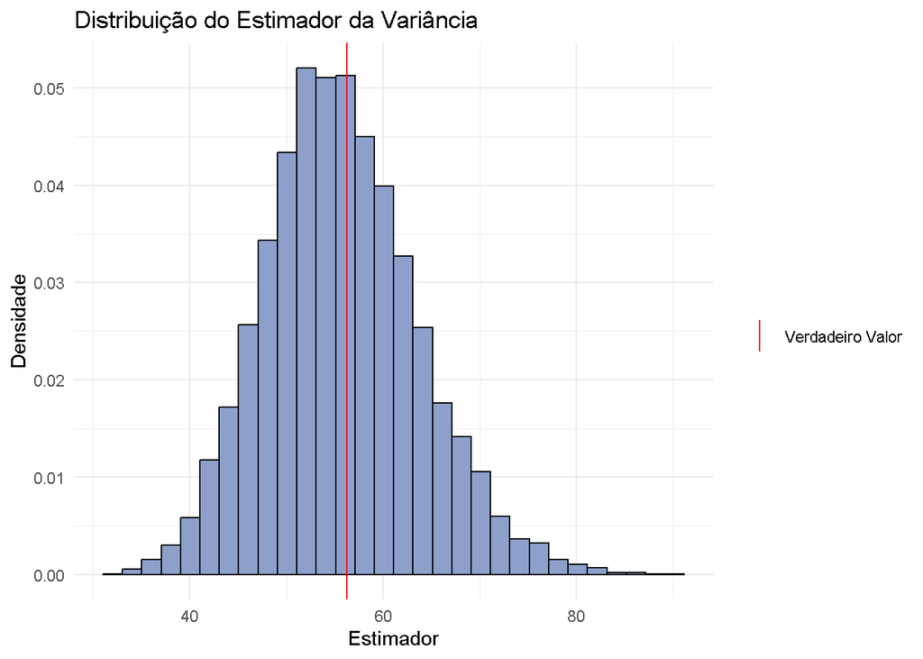

A distribuição tem uma cauda mais longa a direita, o que indica que podemos ter uma superestimação do estimador, isto é, ele ser maior que o verdadeiro valor. A quaestao é quanto ele é maior que o parametro

### 1.1.3 Bies do Estimador

```r
bies <- function(estimador, parametro) {
  bies = mean(estimador) - parametro

  return(bies)
}

#Bies simualdo
bies(estimador = Dist_EstVar, parametro = 7.5^2)
```

```
## [1] -0.5767104
```

```r
#Bies Teorico
esperanca.estimador_var(var = 7.5^2, n = 100) - 7.5^2
```

```
## [1] -0.5625
```

```r
#Erro quadratico médio
EQM <- function(estimador, parametro) {

  eqm = var(estimador) + bies(estimador, parametro)^2

  return(eqm)
}

#Erro Quadratico Simulado
EQM(estimador = Dist_EstVar, parametro = 7.5^2)
```

```
## [1] 62.31134
```

```r
#Erro Quadratico Teorico
variancia.estimador_var(100, 7.5^2)
```

```
## [1] 62.64844
```

Obs. isto é valido para uma amostra de tamanho 100, pois como visto o tamanho da amostra altera o valor da variancia, consequentemente o erro quadratico

# 2. Estimadores Eficientes e Estatísticas Suficientes

## 2.1 Estimadores Eficientes

## 2.2 Estimadores Suficientes

## 2.3 Familia Exponencial

## 2.4 Estimadores baseados em Estatísticas Suficientes